# Part I - Ford-Go-Bike, Bike-Sharing System

## Preliminary Wrangling

```python
# import all packages and set plots to be embedded inline
import numpy as np
import pandas as pd
import matplotlib.pyplot as plt
import seaborn as sb

%matplotlib inline
```

#### Load the data set and describe

```python
#Load the data set and display
df=pd.read_csv('201902-fordgobike-tripdata.csv')
df.sample(10)
```

|  | duration_sec | start_time | end_time | start_station_id | start_station_name | start_station_latitude | start_station_longitude | end_station_id | end_station_name | end_station_latitude | end_station_longitude | bike_id | user_type | member_birth_year | member_gender | bike_share_for_all_trip |
| --- | --- | --- | --- | --- | --- | --- | --- | --- | --- | --- | --- | --- | --- | --- | --- | --- |
| 92505 | 148 | 2019-02-15 18:55:43.0360 | 2019-02-15 18:58:11.8840 | 267.0 | Derby St at College Ave | 37.861804 | -122.253569 | 269.0 | Telegraph Ave at Carleton St | 37.862320 | -122.258801 | 5461 | Subscriber | 1998.0 | Male | No |
| 129959 | 699 | 2019-02-09 21:29:07.9060 | 2019-02-09 21:40:47.4330 | 357.0 | 2nd St at Julian St | 37.341132 | -121.892844 | 314.0 | Santa Clara St at Almaden Blvd | 37.333988 | -121.894902 | 3810 | Subscriber | 1995.0 | Male | Yes |
| 138827 | 700 | 2019-02-08 05:41:10.2810 | 2019-02-08 05:52:50.4040 | 58.0 | Market St at 10th St | 37.776619 | -122.417385 | 16.0 | Steuart St at Market St | 37.794130 | -122.394430 | 4799 | Subscriber | NaN | NaN | No |
| 79263 | 1317 | 2019-02-18 17:35:20.7730 | 2019-02-18 17:57:18.0020 | 176.0 | MacArthur BART Station | 37.828410 | -122.266315 | 155.0 | Emeryville Public Market | 37.840521 | -122.293528 | 2450 | Customer | 1995.0 | Male | No |
| 174815 | 242 | 2019-02-02 16:38:45.5370 | 2019-02-02 16:42:48.2850 | 112.0 | Harrison St at 17th St | 37.763847 | -122.413004 | 114.0 | Rhode Island St at 17th St | 37.764478 | -122.402570 | 4729 | Subscriber | 1957.0 | Male | No |
| 120544 | 157 | 2019-02-11 17:01:44.7420 | 2019-02-11 17:04:21.8820 | 241.0 | Ashby BART Station | 37.852477 | -122.270213 | 385.0 | Woolsey St at Sacramento St | 37.850578 | -122.278175 | 4526 | Subscriber | 1968.0 | Male | No |
| 77098 | 344 | 2019-02-19 07:42:43.8780 | 2019-02-19 07:48:28.2180 | 50.0 | 2nd St at Townsend St | 37.780526 | -122.390288 | 364.0 | China Basin St at 3rd St | 37.772000 | -122.389970 | 4400 | Subscriber | 1988.0 | Male | No |
| 164087 | 289 | 2019-02-05 08:47:05.8040 | 2019-02-05 08:51:55.7060 | 267.0 | Derby St at College Ave | 37.861804 | -122.253569 | 243.0 | Bancroft Way at College Ave | 37.869360 | -122.254337 | 1129 | Subscriber | 1961.0 | Male | No |
| 124597 | 582 | 2019-02-11 08:23:42.1320 | 2019-02-11 08:33:24.4930 | 41.0 | Golden Gate Ave at Polk St | 37.781270 | -122.418740 | 21.0 | Montgomery St BART Station (Market St at 2nd St) | 37.789625 | -122.400811 | 5479 | Subscriber | 1980.0 | Male | No |
| 116259 | 470 | 2019-02-12 07:59:19.7720 | 2019-02-12 08:07:10.5000 | 66.0 | 3rd St at Townsend St | 37.778742 | -122.392741 | 15.0 | San Francisco Ferry Building (Harry Bridges Pl... | 37.795392 | -122.394203 | 4445 | Subscriber | 1984.0 | Male | No |

### What is the structure of this dataset?

```python
df.shape
```

```
(183412, 16)
```

```python
df.info()
```

```
<class 'pandas.core.frame.DataFrame'>
RangeIndex: 183412 entries, 0 to 183411
Data columns (total 16 columns):
 #   Column                   Non-Null Count   Dtype
---  ------                   --------------   -----
 0   duration_sec             183412 non-null  int64
 1   start_time               183412 non-null  object
 2   end_time                 183412 non-null  object
 3   start_station_id         183215 non-null  float64
 4   start_station_name       183215 non-null  object
 5   start_station_latitude   183412 non-null  float64
 6   start_station_longitude  183412 non-null  float64
 7   end_station_id           183215 non-null  float64
 8   end_station_name         183215 non-null  object
 9   end_station_latitude     183412 non-null  float64
 10  end_station_longitude    183412 non-null  float64
 11  bike_id                  183412 non-null  int64
 12  user_type                183412 non-null  object
 13  member_birth_year        175147 non-null  float64
 14  member_gender            175147 non-null  object
 15  bike_share_for_all_trip  183412 non-null  object
dtypes: float64(7), int64(2), object(7)
memory usage: 22.4+ MB
```

```python
df.describe().transpose()
```

|  | count | mean | std | min | 25% | 50% | 75% | max |
| --- | --- | --- | --- | --- | --- | --- | --- | --- |
| duration_sec | 183412.0 | 726.078435 | 1794.389780 | 61.000000 | 325.000000 | 514.000000 | 796.000000 | 85444.000000 |
| start_station_id | 183215.0 | 138.590427 | 111.778864 | 3.000000 | 47.000000 | 104.000000 | 239.000000 | 398.000000 |
| start_station_latitude | 183412.0 | 37.771223 | 0.099581 | 37.317298 | 37.770083 | 37.780760 | 37.797280 | 37.880222 |
| start_station_longitude | 183412.0 | -122.352664 | 0.117097 | -122.453704 | -122.412408 | -122.398285 | -122.286533 | -121.874119 |
| end_station_id | 183215.0 | 136.249123 | 111.515131 | 3.000000 | 44.000000 | 100.000000 | 235.000000 | 398.000000 |
| end_station_latitude | 183412.0 | 37.771427 | 0.099490 | 37.317298 | 37.770407 | 37.781010 | 37.797320 | 37.880222 |
| end_station_longitude | 183412.0 | -122.352250 | 0.116673 | -122.453704 | -122.411726 | -122.398279 | -122.288045 | -121.874119 |
| bike_id | 183412.0 | 4472.906375 | 1664.383394 | 11.000000 | 3777.000000 | 4958.000000 | 5502.000000 | 6645.000000 |
| member_birth_year | 175147.0 | 1984.806437 | 10.116689 | 1878.000000 | 1980.000000 | 1987.000000 | 1992.000000 | 2001.000000 |

```python
df.isnull().sum()
```

```
duration_sec                  0
start_time                    0
end_time                      0
start_station_id            197
start_station_name          197
start_station_latitude        0
start_station_longitude       0
end_station_id              197
end_station_name            197
end_station_latitude          0
end_station_longitude         0
bike_id                       0
user_type                     0
member_birth_year          8265
member_gender              8265
bike_share_for_all_trip       0
dtype: int64
```

```python
df.duplicated().sum()
```

```
0
```

### What are the Issues with the dataset?

1. Some data types are wrong
2. A number of null values
3. Needs an age column
4. Duration will be easier to manage in minutes than Seconds thus has to be changed
5. Creating a start day Column

##### 1.Change data types

```python
#Changing date function
df['start_time']=pd.to_datetime(df['start_time'])
df['end_time']=pd.to_datetime(df['end_time'])
```

```python
df.info()
```

```
<class 'pandas.core.frame.DataFrame'>
RangeIndex: 183412 entries, 0 to 183411
Data columns (total 16 columns):
 #   Column                   Non-Null Count   Dtype
---  ------                   --------------   -----
 0   duration_sec             183412 non-null  int64
 1   start_time               183412 non-null  datetime64[ns]
 2   end_time                 183412 non-null  datetime64[ns]
 3   start_station_id         183215 non-null  float64
 4   start_station_name       183215 non-null  object
 5   start_station_latitude   183412 non-null  float64
 6   start_station_longitude  183412 non-null  float64
 7   end_station_id           183215 non-null  float64
 8   end_station_name         183215 non-null  object
 9   end_station_latitude     183412 non-null  float64
 10  end_station_longitude    183412 non-null  float64
 11  bike_id                  183412 non-null  int64
 12  user_type                183412 non-null  object
 13  member_birth_year        175147 non-null  float64
 14  member_gender            175147 non-null  object
 15  bike_share_for_all_trip  183412 non-null  object
dtypes: datetime64[ns](2), float64(7), int64(2), object(5)
memory usage: 22.4+ MB
```

##### 2.Changing duration to minutes

```python
df['duration_minute'] = df['duration_sec']/60
df= df.drop(['duration_sec'], axis = 1)
df['duration_minute'] = df['duration_minute'].astype(int)
df.head()
```

|  | start_time | end_time | start_station_id | start_station_name | start_station_latitude | start_station_longitude | end_station_id | end_station_name | end_station_latitude | end_station_longitude | bike_id | user_type | member_birth_year | member_gender | bike_share_for_all_trip | duration_minute |
| --- | --- | --- | --- | --- | --- | --- | --- | --- | --- | --- | --- | --- | --- | --- | --- | --- |
| 0 | 2019-02-28 17:32:10.145 | 2019-03-01 08:01:55.975 | 21.0 | Montgomery St BART Station (Market St at 2nd St) | 37.789625 | -122.400811 | 13.0 | Commercial St at Montgomery St | 37.794231 | -122.402923 | 4902 | Customer | 1984.0 | Male | No | 869 |
| 1 | 2019-02-28 18:53:21.789 | 2019-03-01 06:42:03.056 | 23.0 | The Embarcadero at Steuart St | 37.791464 | -122.391034 | 81.0 | Berry St at 4th St | 37.775880 | -122.393170 | 2535 | Customer | NaN | NaN | No | 708 |
| 2 | 2019-02-28 12:13:13.218 | 2019-03-01 05:24:08.146 | 86.0 | Market St at Dolores St | 37.769305 | -122.426826 | 3.0 | Powell St BART Station (Market St at 4th St) | 37.786375 | -122.404904 | 5905 | Customer | 1972.0 | Male | No | 1030 |
| 3 | 2019-02-28 17:54:26.010 | 2019-03-01 04:02:36.842 | 375.0 | Grove St at Masonic Ave | 37.774836 | -122.446546 | 70.0 | Central Ave at Fell St | 37.773311 | -122.444293 | 6638 | Subscriber | 1989.0 | Other | No | 608 |
| 4 | 2019-02-28 23:54:18.549 | 2019-03-01 00:20:44.074 | 7.0 | Frank H Ogawa Plaza | 37.804562 | -122.271738 | 222.0 | 10th Ave at E 15th St | 37.792714 | -122.248780 | 4898 | Subscriber | 1974.0 | Male | Yes | 26 |

##### 3.Creat age column

```python
df['age'] = 2019 - df['member_birth_year']
df= df.drop(['member_birth_year'], axis = 1)
df['age'] = df['age'].fillna(0).astype(int)
df.head()
```

|  | start_time | end_time | start_station_id | start_station_name | start_station_latitude | start_station_longitude | end_station_id | end_station_name | end_station_latitude | end_station_longitude | bike_id | user_type | member_gender | bike_share_for_all_trip | duration_minute | age |
| --- | --- | --- | --- | --- | --- | --- | --- | --- | --- | --- | --- | --- | --- | --- | --- | --- |
| 0 | 2019-02-28 17:32:10.145 | 2019-03-01 08:01:55.975 | 21.0 | Montgomery St BART Station (Market St at 2nd St) | 37.789625 | -122.400811 | 13.0 | Commercial St at Montgomery St | 37.794231 | -122.402923 | 4902 | Customer | Male | No | 869 | 35 |
| 1 | 2019-02-28 18:53:21.789 | 2019-03-01 06:42:03.056 | 23.0 | The Embarcadero at Steuart St | 37.791464 | -122.391034 | 81.0 | Berry St at 4th St | 37.775880 | -122.393170 | 2535 | Customer | NaN | No | 708 | 0 |
| 2 | 2019-02-28 12:13:13.218 | 2019-03-01 05:24:08.146 | 86.0 | Market St at Dolores St | 37.769305 | -122.426826 | 3.0 | Powell St BART Station (Market St at 4th St) | 37.786375 | -122.404904 | 5905 | Customer | Male | No | 1030 | 47 |
| 3 | 2019-02-28 17:54:26.010 | 2019-03-01 04:02:36.842 | 375.0 | Grove St at Masonic Ave | 37.774836 | -122.446546 | 70.0 | Central Ave at Fell St | 37.773311 | -122.444293 | 6638 | Subscriber | Other | No | 608 | 30 |
| 4 | 2019-02-28 23:54:18.549 | 2019-03-01 00:20:44.074 | 7.0 | Frank H Ogawa Plaza | 37.804562 | -122.271738 | 222.0 | 10th Ave at E 15th St | 37.792714 | -122.248780 | 4898 | Subscriber | Male | Yes | 26 | 45 |

##### 4.Creating start day column

```python
df['start_day'] = df['start_time'].dt.day_name()
df.sample(10)
```

|  | start_time | end_time | start_station_id | start_station_name | start_station_latitude | start_station_longitude | end_station_id | end_station_name | end_station_latitude | end_station_longitude | bike_id | user_type | member_gender | bike_share_for_all_trip | duration_minute | age | start_day |
| --- | --- | --- | --- | --- | --- | --- | --- | --- | --- | --- | --- | --- | --- | --- | --- | --- | --- |
| 16965 | 2019-02-27 07:51:57.308 | 2019-02-27 07:58:01.976 | 233.0 | 4th Ave at E 12th St (Temporary Location) | 37.795913 | -122.255547 | 46.0 | San Antonio Park | 37.790140 | -122.242373 | 6422 | Subscriber | Male | No | 6 | 31 | Wednesday |
| 166960 | 2019-02-04 17:44:22.071 | 2019-02-04 18:01:57.422 | 139.0 | Garfield Square (25th St at Harrison St) | 37.751017 | -122.411901 | 95.0 | Sanchez St at 15th St | 37.766219 | -122.431060 | 4756 | Subscriber | Female | No | 17 | 36 | Monday |
| 14542 | 2019-02-27 12:02:20.795 | 2019-02-27 12:09:36.974 | 16.0 | Steuart St at Market St | 37.794130 | -122.394430 | 9.0 | Broadway at Battery St | 37.798572 | -122.400869 | 5504 | Subscriber | NaN | No | 7 | 0 | Wednesday |
| 121438 | 2019-02-11 15:18:54.571 | 2019-02-11 15:23:51.081 | 249.0 | Russell St at College Ave | 37.858473 | -122.253253 | 243.0 | Bancroft Way at College Ave | 37.869360 | -122.254337 | 4666 | Subscriber | Male | No | 4 | 29 | Monday |
| 91583 | 2019-02-16 01:40:58.531 | 2019-02-16 01:50:13.161 | 317.0 | San Salvador St at 9th St | 37.333955 | -121.877349 | 305.0 | Ryland Park | 37.342725 | -121.895617 | 3843 | Subscriber | Male | Yes | 9 | 26 | Saturday |
| 90061 | 2019-02-16 13:43:44.222 | 2019-02-16 13:56:56.874 | 173.0 | Shattuck Ave at 55th St | 37.840364 | -122.264488 | 181.0 | Grand Ave at Webster St | 37.811377 | -122.265192 | 1861 | Subscriber | Male | No | 13 | 45 | Saturday |
| 70407 | 2019-02-19 18:19:20.974 | 2019-02-19 18:28:01.382 | 312.0 | San Jose Diridon Station | 37.329732 | -121.901782 | 378.0 | Empire St at 7th St | 37.347745 | -121.890800 | 6618 | Subscriber | Male | No | 8 | 48 | Tuesday |
| 123836 | 2019-02-11 09:01:12.952 | 2019-02-11 09:08:36.409 | 66.0 | 3rd St at Townsend St | 37.778742 | -122.392741 | 23.0 | The Embarcadero at Steuart St | 37.791464 | -122.391034 | 5350 | Subscriber | Male | No | 7 | 44 | Monday |
| 5232 | 2019-02-28 13:29:13.273 | 2019-02-28 13:47:44.531 | 134.0 | Valencia St at 24th St | 37.752428 | -122.420628 | 67.0 | San Francisco Caltrain Station 2 (Townsend St... | 37.776639 | -122.395526 | 4344 | Customer | Female | No | 18 | 26 | Thursday |
| 10362 | 2019-02-27 20:36:30.876 | 2019-02-27 20:50:00.747 | 280.0 | San Fernando St at 7th St | 37.337122 | -121.883215 | 357.0 | 2nd St at Julian St | 37.341132 | -121.892844 | 3922 | Subscriber | Male | Yes | 13 | 26 | Wednesday |

##### 5.Droping the null values

```python
df.dropna(axis=0,inplace=True)
```

```python
df.isnull().sum()
```

```
start_time                 0
end_time                   0
start_station_id           0
start_station_name         0
start_station_latitude     0
start_station_longitude    0
end_station_id             0
end_station_name           0
end_station_latitude       0
end_station_longitude      0
bike_id                    0
user_type                  0
member_gender              0
bike_share_for_all_trip    0
duration_minute            0
age                        0
start_day                  0
dtype: int64
```

```python
df.info()
```

```
<class 'pandas.core.frame.DataFrame'>
Int64Index: 174952 entries, 0 to 183411
Data columns (total 17 columns):
 #   Column                   Non-Null Count   Dtype
---  ------                   --------------   -----
 0   start_time               174952 non-null  datetime64[ns]
 1   end_time                 174952 non-null  datetime64[ns]
 2   start_station_id         174952 non-null  float64
 3   start_station_name       174952 non-null  object
 4   start_station_latitude   174952 non-null  float64
 5   start_station_longitude  174952 non-null  float64
 6   end_station_id           174952 non-null  float64
 7   end_station_name         174952 non-null  object
 8   end_station_latitude     174952 non-null  float64
 9   end_station_longitude    174952 non-null  float64
 10  bike_id                  174952 non-null  int64
 11  user_type                174952 non-null  object
 12  member_gender            174952 non-null  object
 13  bike_share_for_all_trip  174952 non-null  object
 14  duration_minute          174952 non-null  int32
 15  age                      174952 non-null  int32
 16  start_day                174952 non-null  object
dtypes: datetime64[ns](2), float64(6), int32(2), int64(1), object(6)
memory usage: 22.7+ MB
```

### What is the Structure of your Dataset?

```python
df.info()
```

```
<class 'pandas.core.frame.DataFrame'>
Int64Index: 174952 entries, 0 to 183411
Data columns (total 17 columns):
 #   Column                   Non-Null Count   Dtype
---  ------                   --------------   -----
 0   start_time               174952 non-null  datetime64[ns]
 1   end_time                 174952 non-null  datetime64[ns]
 2   start_station_id         174952 non-null  float64
 3   start_station_name       174952 non-null  object
 4   start_station_latitude   174952 non-null  float64
 5   start_station_longitude  174952 non-null  float64
 6   end_station_id           174952 non-null  float64
 7   end_station_name         174952 non-null  object
 8   end_station_latitude     174952 non-null  float64
 9   end_station_longitude    174952 non-null  float64
 10  bike_id                  174952 non-null  int64
 11  user_type                174952 non-null  object
 12  member_gender            174952 non-null  object
 13  bike_share_for_all_trip  174952 non-null  object
 14  duration_minute          174952 non-null  int32
 15  age                      174952 non-null  int32
 16  start_day                174952 non-null  object
dtypes: datetime64[ns](2), float64(6), int32(2), int64(1), object(6)
memory usage: 22.7+ MB
```

### What features in the dataset do you think will help support your investigation into your feature(s) of interest?

1. Duration of the trips
2. Gender
3. Age
4. The User type
5. The Start station

## Univariate Exploration

This section investigates the distributions of individual variables

```python
def pie(p,t):
    sorted_counts = df[p].value_counts()
    plt.figure(figsize=[10,7])
    plt.pie(sorted_counts, labels = sorted_counts.index, startangle = 90,autopct='%.2f', counterclock = False);
    plt.axis('square')
    plt.legend(loc='upper right');
    plt.title(t,fontsize=16);
```

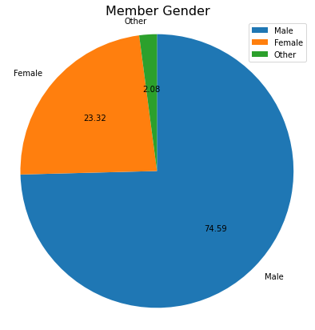

```python
#Member Gender
pie('member_gender','Member Gender')
```

This shows that majority of the users were Males coming in at 74.59%

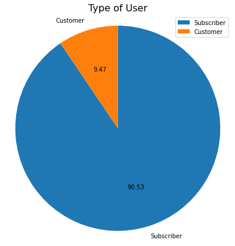

```python
#Pie chart of User Type
pie('user_type', 'Type of User')
```

This shows that majority of the users were Subscribed to Ford-Go-Bikes

```python
#bar function
def bar(a,b,c):
    plt.figure(figsize=[14, 7]);
    base_color = sb.color_palette()[0]
    sb.countplot(data=df, x=a, color=base_color, order= df[a].value_counts().index)
    plt.xlabel(b, fontsize=14)
    plt.ylabel('Count', fontsize=14)
    plt.title(c,fontsize=16);
```

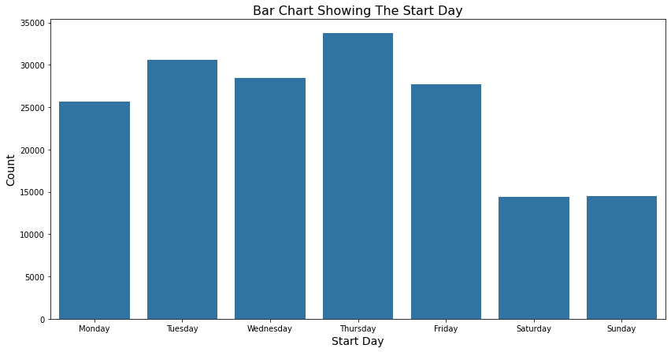

```python
#Start Day Bar Chart Plot
plt.figure(figsize=[14, 7]);
base_color = sb.color_palette()[0]
order = ["Monday","Tuesday","Wednesday","Thursday","Friday","Saturday","Sunday"]
sb.countplot(data=df, x='start_day', color=base_color, order= order)
plt.xlabel('Start Day', fontsize=14)
plt.ylabel('Count', fontsize=14)
plt.title('Bar Chart Showing The Start Day',fontsize=16);
```

This shows that Thursday was the most common day to hire a bike with weekends having the least.

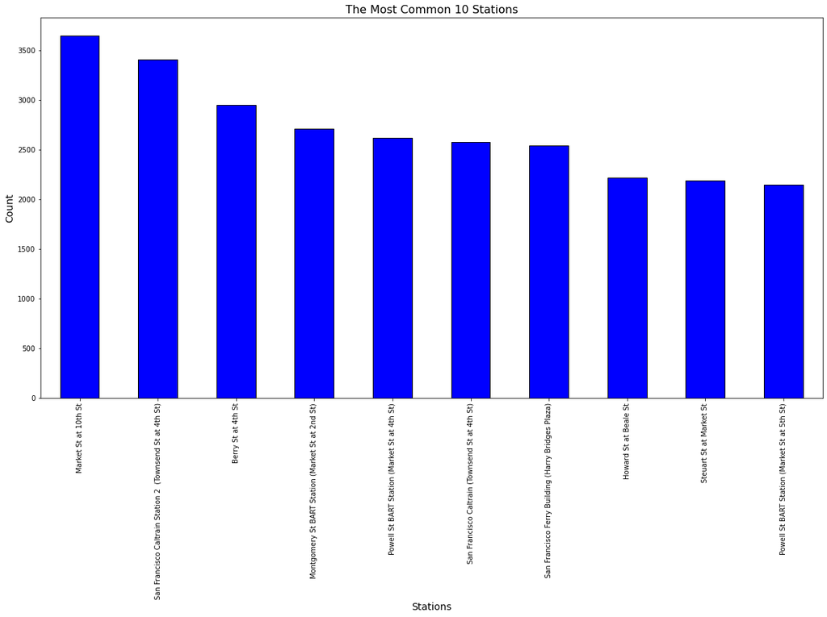

```python
#Most common stations
sations = df['start_station_name'].value_counts()[0:10]
df['start_station_name'].value_counts()[0:10].plot(kind='bar', y='start_station_name', figsize=(20,10),edgecolor='black', color=('blue'), title='The Most Common 10 Stations');
plt.ylabel("Count", size='14');
plt.xlabel("Stations", size='14');
plt.title('The Most Common 10 Stations',fontsize=16);
```

This shows that Market Station at 10th St is the most commom station where usese start

```python
#Creating a Histogram plot function
def hist(a,b,c):
    binsize = 5
    bins = np.arange(0, df[a].max()+binsize, binsize)
    plt.figure(figsize=[10, 5])
    plt.hist(data = df, x = a ,bins=bins)
    plt.xlabel(b, size='14')
    plt.ylabel('Count ', size='14')
    plt.axis([-10, 140, 0, 70000])
    plt.title(c, size='14')
```

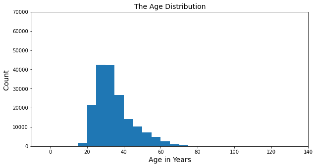

```python
#Histogram showing riders age distribution
hist('age','Age in Years','The Age Distribution')
```

This shows that a majority of the users were between the ages of 20 years to 45years

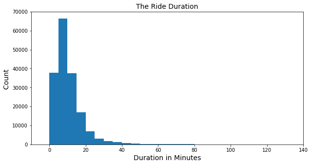

```python
#Trip Duration
hist('duration_minute','Duration in Minutes','The Ride Duration')
```

This shows that most ride durations were between 0-25minutes

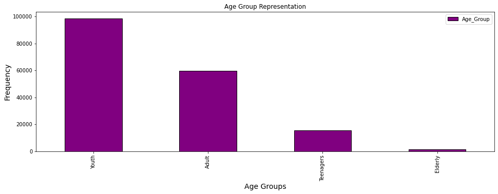

```python
#Creating Bins to group the ages
bins = [18,23,35,65,np.inf]
names = ['Teenagers','Youth','Adult','Elderly']
df['Age_Group']=pd.cut(df['age'],bins , labels = names)
Age_Count_df=df['Age_Group'].value_counts()
Age_Count_df.plot(kind ='bar',figsize = (16,5),  color='purple',edgecolor= 'black', title='Age Group Representation');
plt.xlabel("Age Groups", size='14');
plt.ylabel("Frequency", size='14');
plt.legend();
```

This shows that Youths were the majority of the users with very few eldely individuals(Thode above the age of 65)

### Are there any unusual distributions , changes and transformations ?

1. Yes there a rider who is 140 years old. I found this a bit odd asSomeone that old being able to ride a bike is pretty hard.
2. I reoved the null values, changed datatypes, created new columns:'age','duration_minute'

## Bivariate Exploration

In this section I investigate relationships between pairs of variables in the dataset.

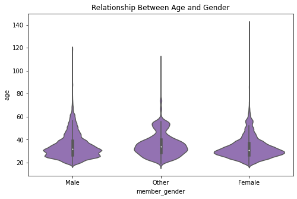

```python
#Comparison of Age in relation to the genders by violin plot
plt.figure(figsize=(8,5))
base_color = sb.color_palette()[4]
sb.violinplot(data = df, x='member_gender', y= 'age', color = base_color)
plt.title('Relationship Between Age and Gender');
```

The majority of the genders had their their highest populatio being between the ages of 20years to 40 years. Also Other genders had a significant portion of its poulation of aroud 50 years using the service.

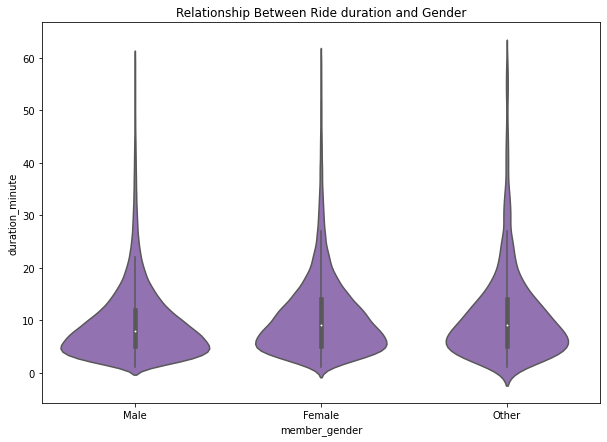

```python
#Comparison of Age in relation to ride duration by violin plot
min = df.query('duration_minute <= 60')
plt.figure(figsize=[10,7])
base_color = sb.color_palette()[4]
sb.violinplot(data = min, x = 'member_gender', y = 'duration_minute',color=base_color)
plt.title('Relationship Between Ride duration and Gender');
```

All genders tend to average 5-10 minutes in ride duration

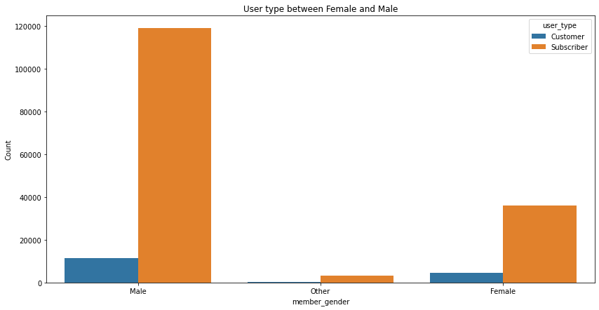

```python
# The type of users in relation to gender
base_color = sb.color_palette()[4]
plt.figure(figsize = [14,7]);
sb.countplot(data=df, x='member_gender',hue='user_type')
plt.xlabel('member_gender')
plt.ylabel('Count')
plt.title('User type between Female and Male');
```

Males where the most users of Ford Go Bikes System and thus tend to have more Male Subscribers same to walk in customers.

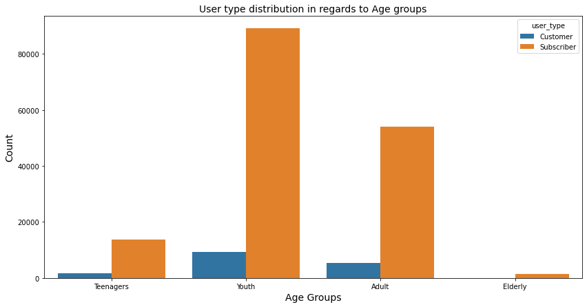

```python
base_color = sb.color_palette()[4]
plt.figure(figsize = [14,7]);
sb.countplot(data=df, x='Age_Group',hue='user_type')
plt.xlabel('Age Groups', size=14)
plt.ylabel('Count', size=14)
plt.title('User type distribution in regards to Age groups', size=14);
```

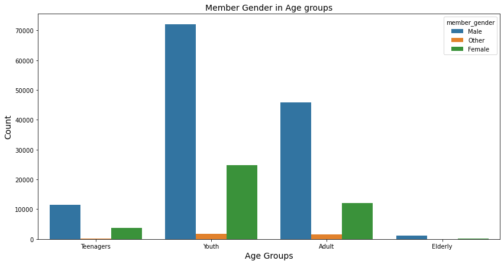

```python
base_color = sb.color_palette()[4]
plt.figure(figsize = [14,7]);
sb.countplot(data=df, x='Age_Group',hue='member_gender')
plt.xlabel('Age Groups', size=14)
plt.ylabel('Count', size=14)
plt.title('Member Gender in Age groups', size=14);
```

Though all age groups The Males were more followed by females and then the other Genders

```python
#Biplot function
def biplot(a,b,c):
    base_color = sb.color_palette()[4]
    plt.figure(figsize = [10,5]);
    sb.countplot(data=df, x=a,hue=b)
    plt.xlabel(b,size=14)
    plt.ylabel('Count',size=14)
    plt.title(c,size=14);
```

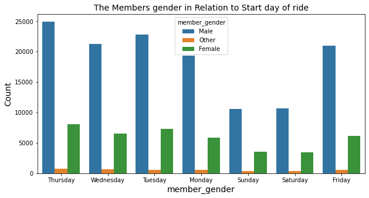

```python
#start day in relation to gender
biplot('start_day','member_gender','The Members gender in Relation to Start day of ride')
```

Though all the days The Males were more followed by females and then the other Genders

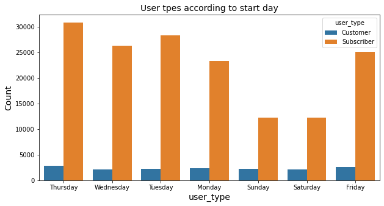

```python
#start day in relation to user type
biplot('start_day','user_type', 'User tpes according to start day')
```

Though all days the subscribers were more than the walk in customers

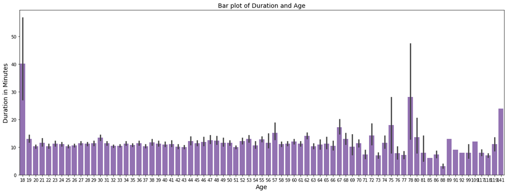

```python
# Bar plot with of age with the duration
plt.figure(figsize = (20,7))
base_color = sb.color_palette()[4]
sb.barplot(data = df, x = 'age', y = 'duration_minute',color=base_color);
plt.xlabel('Age',size='14')
plt.ylabel('Duration in Minutes', size='14')
plt.title('Bar plot of Duration and Age',size=14);
```

From this we can see that there is no direct relation of users age to the distance covered.

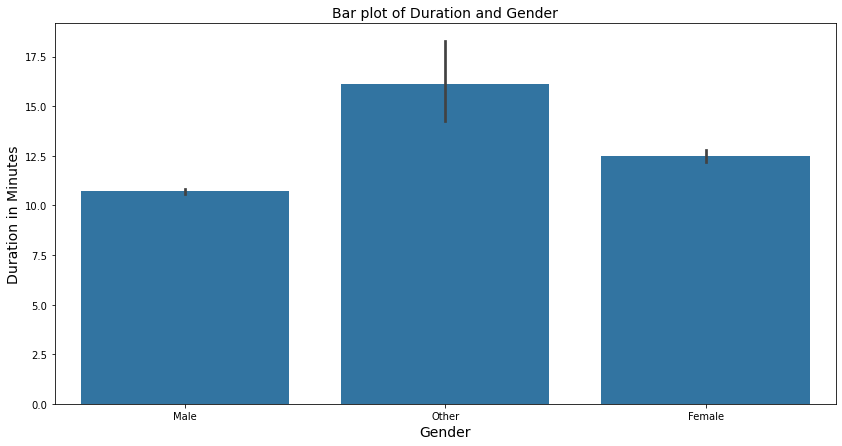

```python
# Regration plot with of age with the duration
plt.figure(figsize = (14,7))
base_color = sb.color_palette()[0]
sb.barplot(data = df, x = 'member_gender', y = 'duration_minute',color=base_color);
plt.xlabel('Gender',size='14')
plt.ylabel('Duration in Minutes', size='14')
plt.title('Bar plot of Duration and Gender',size=14);
```

This shows that the Other Genders had a higher duration on average follwed by the Females with the males having a lower average ride duration.

### How did the features of intrest vary with other features

1. I thought age would have a significant impact on the duration of the ride but from the data we see there is no impact of age on the ride duration

## Multivariate Exploration

Here I create plots of three or more variables to investigate the data set even further

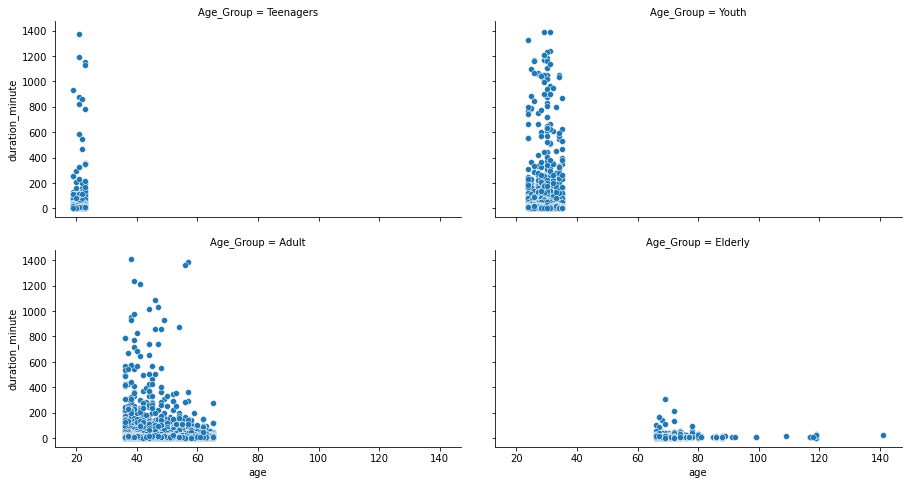

```python
g = sb.FacetGrid(data = df, col = 'Age_Group', col_wrap = 2)
g.map(sb.scatterplot, 'age', 'duration_minute')
g.fig.set_size_inches(14, 7);
```

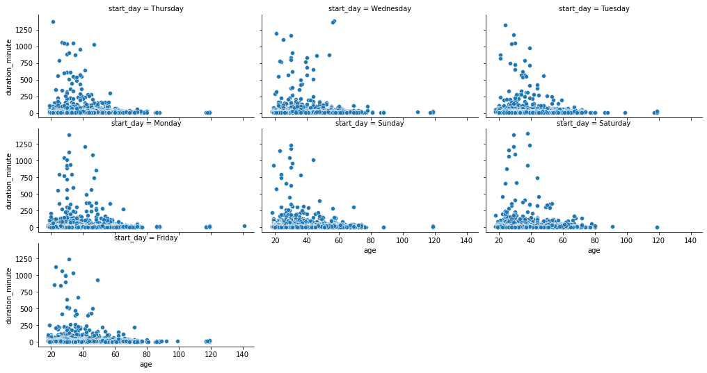

```python
#The Duration and Age Each Day of the Week
g = sb.FacetGrid(data = df, col = 'start_day', col_wrap = 3, height = 6)
g.map(sb.scatterplot, 'age', 'duration_minute')
g.fig.set_size_inches(14, 7);
```

It can be seen that the day of the week has no major to the ride duration as all the days seem to have the same distribution in ride duration

### Where there interesting interactions between the variables?

The service seems to have the same pattern in terms of age and ride duration everyday of the week.

## Conclusions

> 1. There is a more demand for the service during the week as compared to weekends where the demand drops. This may be that most hire the bikes on working days so ast to beat traffic.
> 2. Most of the users are Subscribers comming accounting for 90.53% of the total Users
> 3. Most of the users are males accounting for 74.59
> 4. Most of the users are the Youth foloowed by Adults then Teenagers and then the Elderly.
> 5. Average age of most users was between 20-45years.
> 6. The average ride duration for Other genders was higher then followed by females and finaly the males
> 7. Most rides durations were averagly between 0-25minutes

## Limitations

> The data provided was only for the month of February and thus may not depict the true parterns all year round.